# Confidence Intervals mini lab

```r
library(tidyverse)
library(janitor)
library(infer)

houses <- read_csv("data/ames.csv") %>%
  clean_names()
```

#Question 2 >Plot a histogram of sale_price. Is the distribution normal?

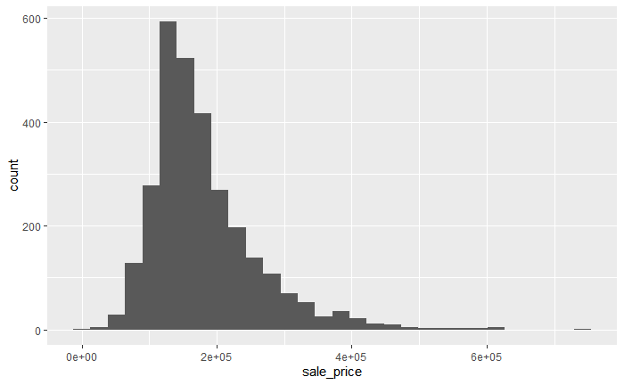

Not a normal distribution.

# Question 3

> Calculate the population parameter mean of sale_price. Store it in a variable, as we’ll need this value later when we check if each CI contains the parameter value or not.

# Question 4

Now we are going to: - take 1000 random samples each of size 100 from sale_price in ames - create a boostrap sampling distribution of mean(sale_price) from each 100-observation sample (use 1000 reps) - calculate the 95% CI for each bootstrap distribution - store the upper and lower bounds of the CI in a tibble called results

Use the infer workflow to generate the bootstrap distributions and CIs. This code will be pretty hard to write. Think about wrapping the sample creation and infer code in a for loop to generate 1000 random samples and CIs. Create an empty results tibble before the loop, and bind_rows() to it every time you generate a new set of CI bounds.

| sample_no | lower_ci | upper_ci |
| --- | --- | --- |
| 1 | 156072.6 | 181632.6 |
| 2 | 166229.3 | 200842.3 |
| 3 | 166671.8 | 199086.0 |
| 4 | 157676.0 | 183623.0 |
| 5 | 168244.4 | 201737.5 |
| 6 | 166183.4 | 193015.9 |
| 7 | 171129.2 | 203779.5 |
| 8 | 178521.5 | 213406.4 |
| 9 | 164513.3 | 195390.1 |
| 10 | 165899.9 | 193433.9 |

[output cut: 990 more lines]

| popn_param_in_ci | propn |
| --- | --- |
| FALSE | 0.063 |
| TRUE | 0.937 |